# D4EJ Tutorials : Intro to R & RStudio

Samantha Sambado

2023-06-05

#### Welcome to Data for Enviornmental Judtice (D4EJ) mini-lessons!

The purpose of these computer labs are to give you hands-on experience with the statistic the **R language** and the **RStudio environment**. This may be your first time coding or hearing about R, which is *really exciting* & will sometimes be frustrating; but that’s totally normal.

##### Outline

- Background on R and RStudio
- Learning objectives
- Mini-lesson instructions
- Mini-lesson material
- Mini-lesson questions/assessment

### Background on R and RStudio

*note: much of this info came from other coding classes I have taken at UCSB that I highly recommend such as UCSB EEMB 179 with Dr. Holly Moeller & UCSB ESM 206 with Dr. Allison Horst*

**What is R and RStudio?**

TLDR; R is a programming language whereas RStudio is a user-friendly platform to visualize R tasks.

R is an object-oriented scripting language that combines:

- An extensive set of functions for classical & modern **statistical data analysis & modeling**
- Graphing functions for **visualizing data & model output**
- **free and open source tool** to be shared with a wider internet community

**What’s the difference between .Rmd vs .html vs.R files?**

- Both .Rmd and .html file types contain the same information – code we need to run & text that describes the code. However, the .Rmd file will contain extra code which formats the .html document. We will typically start in an .Rmd file to write and execute code, however once completed with code, the .html file may be more visually appealing to read.
- R script (.R file) have less functionality as it relates to data visualization, code organization and output generation.

### Intro to R & RStudio “Intro”

#### Learning objectives

1. Become familiar with R language and RStudio environment – at least have it **working on your personal computer**
2. **Correctly identify data types** of variables
3. Observe common **data wrangling techniques** in tidyverse
4. Learn some common terminology in R – to help with asking questions

### Part 2: Material for HW Assignment questions

For this week only, you will **answer multiple choice questions on GauchoSpace** in lieu of uploading a PDF or .html file of your homework answers. The link to these questions can be found on WEEK 1 COMPUTER LAB MATERIALS labeled, **‘Lab 1 HW Assignment Questions (answer these)’**. For **HW Assignment Lab 1 you do not need to upload any files**, you just need to read through this .html file to find the information to **answer the questions directly on GauchoSpace**. All GauchoSpace questions can be answered through material found on this .html document, **you do not need to consult any other material sources** (ie Google).

#### A. The Big Picture

So much data exists in our world! With R, you have the ability to use that data to ask and answer questions. There are many ways to tell a story, but there are some general guidelines on how to build that story:

- First ask yourself, what is your outcome of interest - your **dependent** variable ‘y’?
- Then ponder, what is influencing your outcome of interest - your **independent** variable ‘x’?

Some questions you may have that R could theoretically solve for you:

- Does soil type (**independent**) influence tree height (**dependent**)?
- Does the distance from ocean (**independent**) influence rent costs (**dependent**)?
- Do twitter mentions (**independent**) influence cryptocurrency value (**dependent**)?

[figure not shown]

#### B. Your type of data determines how you can shape your story

##### Data types or classes

- **Numerical** –> numbers, duh.
  - *example: 1, 4.03, 7000*
- **Categorical** –> characteristics, like words.
  - *example: blue, kind, fish*
- **Continuous** –> numbers can take on **any** value
  - *example: height, weight, temperature*
- **Discrete** –> numbers or words can only be **certain** values
  - *example: days of the week, # of kids in a class, pet type*
- **Factor** –> categorical grouping
  - *example: cereals, departments, countries*
- **Levels** –> categorical sub-groups of factors
  - *example: (honey bunches of oats, cheerios), (EEMB, PSTAT, ESM), (Canada, USA, Mexico)*
- **Nominal** –> discrete units with no order
  - *example: languages, countries, gender*
- **Ordinal** –> discrete unites with order
  - *example: months of year, levels of education, TA reviews*

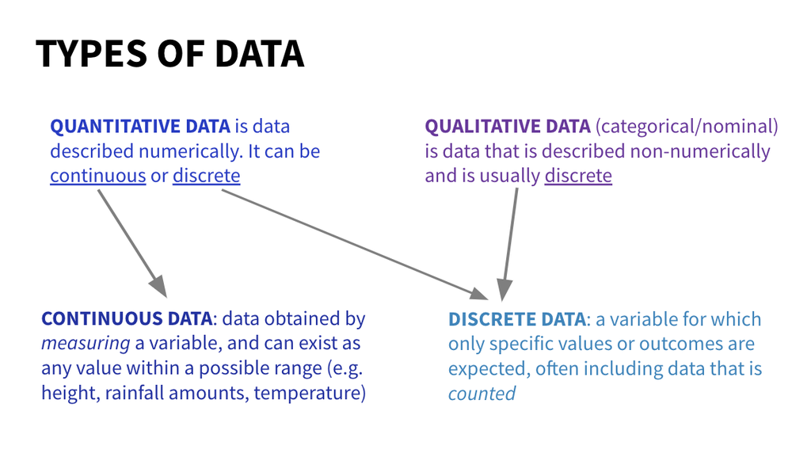

*image from ESM 206 taught by Dr. Allison Horst*

#### C. Once you understand your story, then you can hop into data wrangling - yeehaw.

##### Note

- Data wrangling will require a lot of wrangling

[figure not shown]

- Be prepared to try **a lot** of different stuff

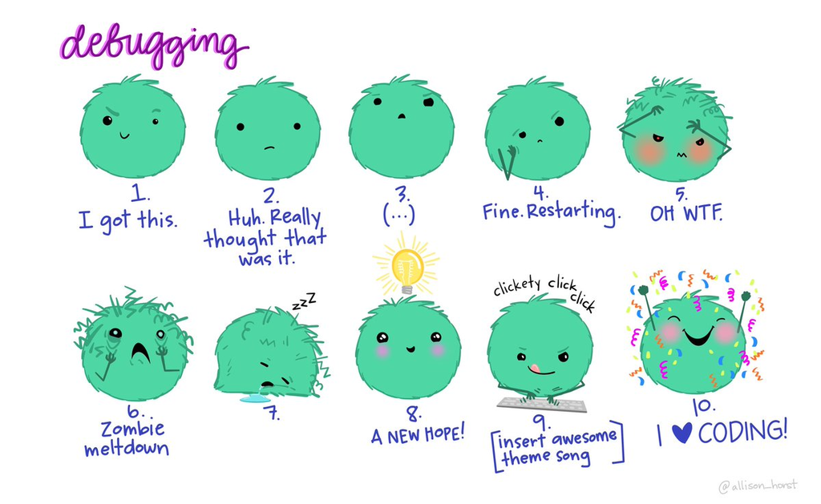

Quick remark, there are many ways to wrangle data. Two common “philosophies” on data wrangling fall under **base-R** or **tidyverse**. **Base-R** works more with individual vectors whereas **tidyverse** (specifically the `dplyr` package) uses verb inputs. Both techniques will be used in this class because they **both achieve similar things**, however choose whatever method makes more intuitive sense to you. You can find more information about the differences on this [link](https://dplyr.tidyverse.org/articles/base.html).

Okay, end of philosophical ramble. Let’s get started.

#### D. Intro to one of the best data wrangling tools – Tidyverse

#### Tidyverse isn’t just a package, it’s a collection of packages

- *similar to how universities (ie tidyverse) are made up of colleges (ie packages) that have specific functions*

##### Rules

- Each **variable** has its own **column**
- Each **observation** has its own **row**
- Each **value** has its own **cell**

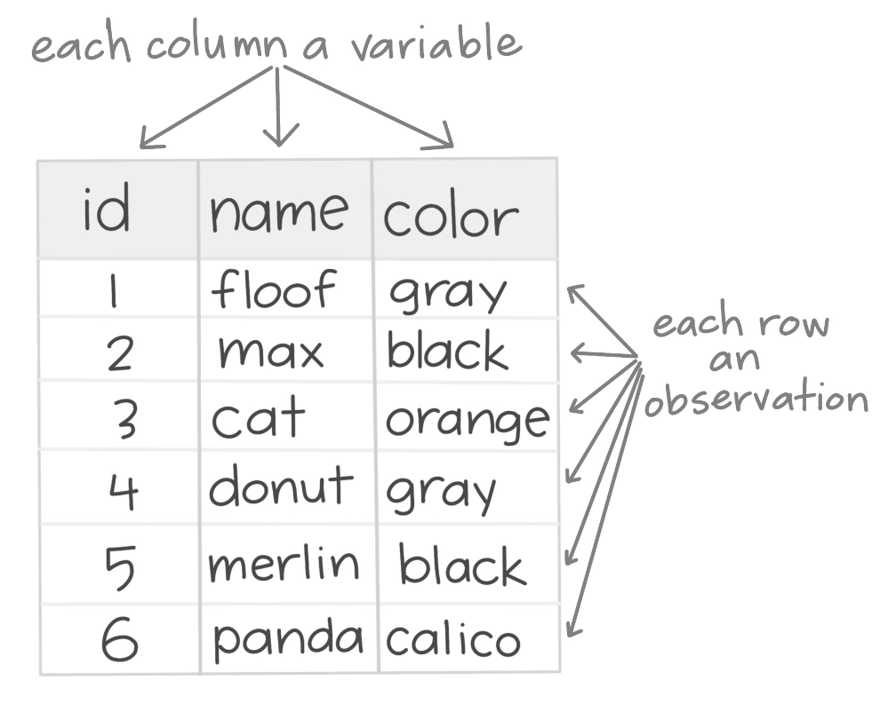

*image from ESM 206 taught by Dr. Allison Horst*

##### Additional Resources - check ’em out!

*Note: Script for this workshop was largely taken from these sources*

[Basic Tidyverse Concepts](https://homerhanumat.github.io/r-notes/tidyverse-concepts.html)

[Tidyverse with animations](https://www.garrickadenbuie.com/project/tidyexplain/)

[Tidyverse-cookbook](https://rstudio-education.github.io/tidyverse-cookbook/tidy.html)

##### Core concepts and commands of tidyverse

*Note: This code serves as a template for future homework help. You don’t need to type out anything. For now, just observe the code and the associated outputs. Think of these exercises as scaffolds for your future code – no need to reinvent the wheel for any of your homework assignments, take code from your exercises to tailor it to specific homework problems.*

##### Step 0: The set up

```r
knitr::opts_chunk$set(echo = TRUE) # this means your code will be generated alongside your output (ie data visuals/model summaries)
knitr::opts_chunk$set(message = FALSE) # this means the message from commands won't be printed out in the .html file
knitr::opts_chunk$set(warning = FALSE) # this means the warning from commands won't be printed out in the .html file


### FYI, basic command line structure ###
    # object <- function(argument)
```

**Step 1. Libraries needed for this workshop**

```r
# remember, install.packages("PACAKGE") then library(PACKAGE)
  ## Note: quotations for install.packages(), no quotations for libary()

# you only need to install a package once to call the library

# after you install.packages(), then hashtag # install.packages()

# install.packages("tidyverse")
library(tidyverse) # package to use tidyverse functions

# install.packages("nycflights13")
library(nycflights13) # package to call data from

# install.packages("mosaicData")
library(mosaicData) # package to call data from
```

**Step 2. Data needed for this assignment**

```r
## we will be using online datasets so we don't have to worry about file paths for now. There are many ways to call in data from the internet compared to when you are uploading a dataset from your own Rproj

# data from github for examples

# dataset 1 for examples
data("flights", package = "nycflights13") # data built into R for exercises

# dataset 2 for examples
data(CPS85) # comes from package `mosaicData`
```

**Step 3. Familiarize with the basics**

##### pipe operator `%>` : chains function together

```r
# using pipe operator
"hello" %>% rep(times = 4)
```

```
## [1] "hello" "hello" "hello" "hello"
```

```r
# without pipe operator
rep("hello", times = 4)
```

```
## [1] "hello" "hello" "hello" "hello"
```